# Diabetes Prevalence in U.S. Adults: Men vs. Women Across States

PROPEL Introduction to R and Statistics - Final Project

Yeison Samayoa Hernandez

November 02, 2026

## Introduction

Diabetes is one of the most common chronic diseases in the U.S. For this project I wanted to know if diabetes is more common in men or in women, and whether that pattern holds up across states. I also looked at how a state’s adult obesity rate relates to its diabetes rate, since obesity is a well-known risk factor for type 2 diabetes.

**Research question:** In 2022, did adult men and women in U.S. states have different diabetes prevalence?

## Packages

```r
library(tidyverse)
```

## The dataset

The data come from the **U.S. Chronic Disease Indicators (CDI)** published by the CDC on Data.gov (https://catalog.data.gov/dataset/u-s-chronic-disease-indicators). It pulls together state-level estimates for many chronic disease topics from surveys like BRFSS and from vital statistics. Every row is a summary number (for example, the percent of adults in a state with diabetes), so there is no individual-level or private health information in it.

The file was downloaded from Data.gov as `export.csv`. I saved it gzip-compressed (`data/export.csv.gz`) so it fits on GitHub. `read_csv()` opens the compressed file directly.

```r
cdi <- read_csv("data/export.csv.gz", guess_max = 100000)

dim(cdi)
```

```
## [1] 398793     34
```

The full dataset has 398,793 rows and 34 columns, covering 19 topics.

```r
cdi %>%
  count(Topic, sort = TRUE)
```

```
## # A tibble: 19 × 2
##    Topic                                               n
##    <chr>                                           <int>
##  1 Cardiovascular Disease                          42636
##  2 Chronic Obstructive Pulmonary Disease           36778
##  3 Alcohol                                         32913
##  4 Nutrition, Physical Activity, and Weight Status 32712
##  5 Health Status                                   32093
##  6 Non-Medical Factors                             27507
##  7 Cancer                                          27432
##  8 Arthritis                                       25190
##  9 Immunization                                    23925
## 10 Diabetes                                        22599
## 11 Mental Health                                   21883
## 12 Tobacco                                         21153
## 13 Asthma                                          13813
## 14 Oral Health                                     13508
## 15 Cognitive Health and Caregiving                  9900
## 16 Sleep                                            6712
## 17 Disability                                       6325
## 18 Maternal Health                                  1298
## 19 Chronic Kidney Disease                            416
```

## Cleaning and filtering

The dataset mixes many different indicators, units, and groupings, so I only kept what I needed:

- **Question:** “Diabetes among adults” (plus “Obesity among adults” for the regression section)
- **Data source:** BRFSS (both questions come from this telephone survey)
- **Year:** 2022, the most recent year with values for all 50 states and DC
- **Value type:** age-adjusted prevalence (%). Age-adjusting matters here because states have different age structures, and diabetes is much more common in older adults.
- **Locations:** the 50 states + DC. I removed the national total (“US”) and the territories (Guam, Puerto Rico, Virgin Islands) so each row is one state.

```r
diabetes <- cdi %>%
  filter(Question == "Diabetes among adults",
         DataSource == "BRFSS",
         YearStart == 2022,
         DataValueType == "Age-adjusted Prevalence",
         !LocationAbbr %in% c("US", "GU", "PR", "VI")) %>%
  select(LocationAbbr, LocationDesc, StratificationCategory1, Stratification1,
         DataValue, LowConfidenceLimit, HighConfidenceLimit)

count(diabetes, StratificationCategory1)
```

```
## # A tibble: 3 × 2
##   StratificationCategory1     n
##   <chr>                   <int>
## 1 Overall                    51
## 2 Race/Ethnicity            357
## 3 Sex                       102
```

For the sex comparison I kept the Male and Female rows and checked for missing values.

```r
diabetes_sex <- diabetes %>%
  filter(StratificationCategory1 == "Sex") %>%
  rename(state = LocationAbbr, sex = Stratification1, prevalence = DataValue)

sum(is.na(diabetes_sex$prevalence))
```

```
## [1] 0
```

```r
n_distinct(diabetes_sex$state)
```

```
## [1] 51
```

There are no missing values, and there are 51 locations with one value for men and one for women.

## Descriptive analysis

### Variables

- `state` (categorical): 50 states + DC
- `sex` (categorical): Male or Female
- `prevalence` (continuous): age-adjusted percent of adults who have ever been told by a doctor they have diabetes

### Summary statistics by sex

```r
sex_summary <- diabetes_sex %>%
  group_by(sex) %>%
  summarize(n_states = n(),
            mean = mean(prevalence),
            sd = sd(prevalence),
            median = median(prevalence),
            min = min(prevalence),
            max = max(prevalence))

sex_summary
```

```
## # A tibble: 2 × 7
##   sex    n_states  mean    sd median   min   max
##   <chr>     <int> <dbl> <dbl>  <dbl> <dbl> <dbl>
## 1 Female       51  9.78  2.16    9.4   6.3  15
## 2 Male         51 11.0   1.76   11.1   7.2  14.8
```

Across states, the average diabetes prevalence was 11% for men and 9.8% for women.

### Bar plot: mean prevalence by sex

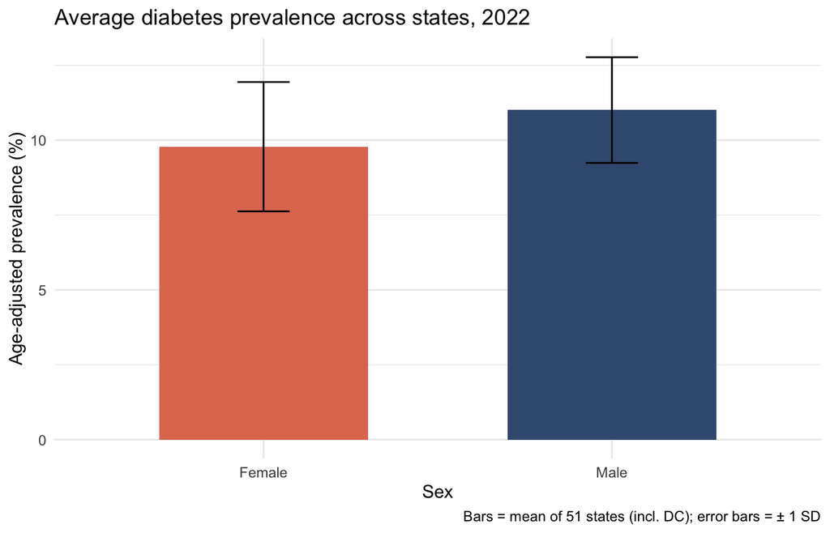

```r
ggplot(sex_summary, aes(x = sex, y = mean, fill = sex)) +
  geom_col(width = 0.6) +
  geom_errorbar(aes(ymin = mean - sd, ymax = mean + sd), width = 0.15) +
  scale_fill_manual(values = c("Female" = "#E07A5F", "Male" = "#3D5A80")) +
  labs(title = "Average diabetes prevalence across states, 2022",
       x = "Sex", y = "Age-adjusted prevalence (%)",
       caption = "Bars = mean of 51 states (incl. DC); error bars = ± 1 SD") +
  theme_minimal() +
  theme(legend.position = "none")
```

### Histogram: overall state diabetes prevalence

```r
diabetes_overall <- diabetes %>%
  filter(StratificationCategory1 == "Overall") %>%
  rename(state = LocationAbbr, prevalence = DataValue)

summary(diabetes_overall$prevalence)
```

```
##    Min. 1st Qu.  Median    Mean 3rd Qu.    Max.
##    7.00    9.00   10.20   10.34   11.30   14.60
```

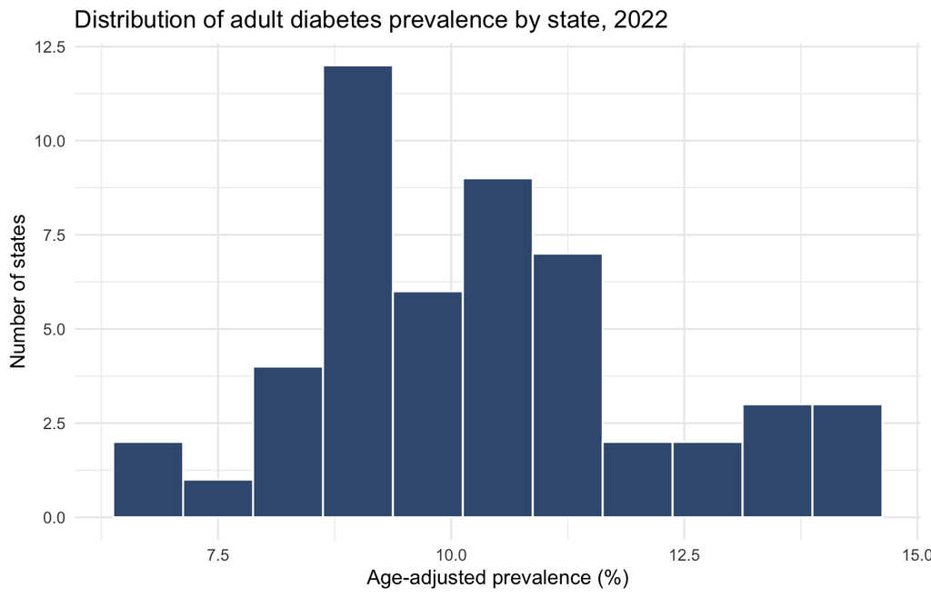

```r
ggplot(diabetes_overall, aes(x = prevalence)) +
  geom_histogram(binwidth = 0.75, fill = "#3D5A80", color = "white") +
  labs(title = "Distribution of adult diabetes prevalence by state, 2022",
       x = "Age-adjusted prevalence (%)", y = "Number of states") +
  theme_minimal()
```

State diabetes prevalence ranged from 7% to 14.6%, with a median of 10.2%. The distribution is roughly bell-shaped with a slight tail toward higher values. The highest states were West Virginia, Arkansas, Mississippi, and the lowest were Vermont, Montana, Colorado.

### Comparison plot: men vs. women within each state

Because every state has a value for both sexes, the most useful picture is to connect the two values for each state.

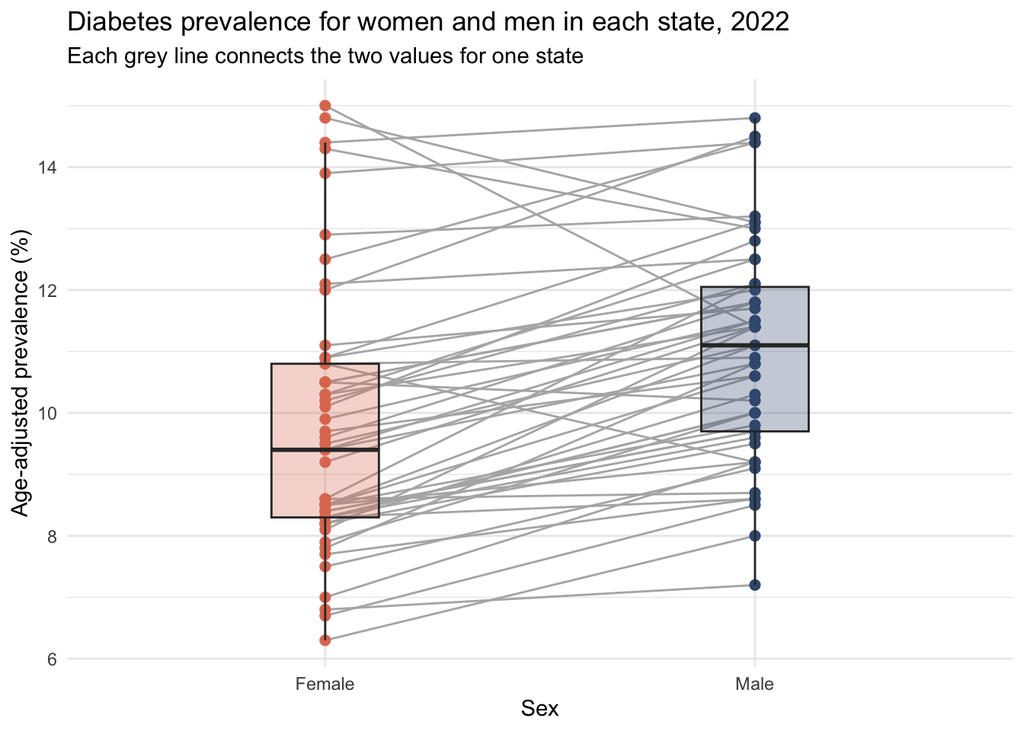

```r
ggplot(diabetes_sex, aes(x = sex, y = prevalence)) +
  geom_line(aes(group = state), color = "grey70") +
  geom_point(aes(color = sex), size = 2) +
  geom_boxplot(aes(fill = sex), width = 0.25, alpha = 0.3, outlier.shape = NA) +
  scale_color_manual(values = c("Female" = "#E07A5F", "Male" = "#3D5A80")) +
  scale_fill_manual(values = c("Female" = "#E07A5F", "Male" = "#3D5A80")) +
  labs(title = "Diabetes prevalence for women and men in each state, 2022",
       subtitle = "Each grey line connects the two values for one state",
       x = "Sex", y = "Age-adjusted prevalence (%)") +
  theme_minimal() +
  theme(legend.position = "none")
```

**Main descriptive findings:** On average, diabetes was more common in men than in women, and most of the grey lines slope upward from women to men. Diabetes prevalence also varied a lot between states, and most of the highest rates were in Southern states.

## Inferential analysis

### Hypotheses

Each state gives two values (men and women), so the two groups are **paired** by state and not independent. That means I need a paired test, comparing the difference within each state.

- **Null hypothesis (H0):** Within states, there is no difference in diabetes prevalence between men and women (the typical male minus female difference is 0).
- **Alternative hypothesis (H1):** Within states, diabetes prevalence differs between men and women.

I used α = 0.05.

### Calculating the paired differences

```r
diabetes_wide <- diabetes_sex %>%
  select(state, LocationDesc, sex, prevalence) %>%
  pivot_wider(names_from = sex, values_from = prevalence) %>%
  mutate(difference = Male - Female)

head(diabetes_wide)
```

```
## # A tibble: 6 × 5
##   state LocationDesc  Male Female difference
##   <chr> <chr>        <dbl>  <dbl>      <dbl>
## 1 NJ    New Jersey    10.6    8.5      2.1
## 2 CO    Colorado       8.5    6.7      1.8
## 3 TN    Tennessee     14.5   12        2.5
## 4 KY    Kentucky      13.2   12.9      0.300
## 5 FL    Florida       11.4    8.1      3.3
## 6 VT    Vermont        7.2    6.8      0.400
```

```r
summary(diabetes_wide$difference)
```

```
##    Min. 1st Qu.  Median    Mean 3rd Qu.    Max.
##  -3.600   0.550   1.300   1.222   2.100   3.500
```

```r
sum(diabetes_wide$difference > 0)
```

```
## [1] 46
```

Men had a higher prevalence than women in 46 of the 51 locations. The few places where women were higher are Louisiana, Mississippi, Alabama, Iowa, Michigan.

### Checking assumptions

A paired t-test assumes the paired differences are roughly normally distributed. I checked this with a histogram, a Q-Q plot, and the Shapiro-Wilk test.

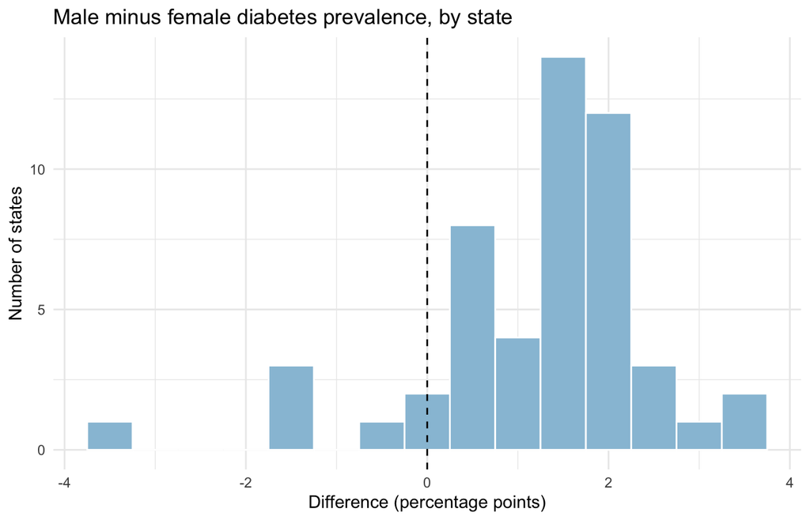

```r
ggplot(diabetes_wide, aes(x = difference)) +
  geom_histogram(binwidth = 0.5, fill = "#98C1D9", color = "white") +
  geom_vline(xintercept = 0, linetype = "dashed") +
  labs(title = "Male minus female diabetes prevalence, by state",
       x = "Difference (percentage points)", y = "Number of states") +
  theme_minimal()
```

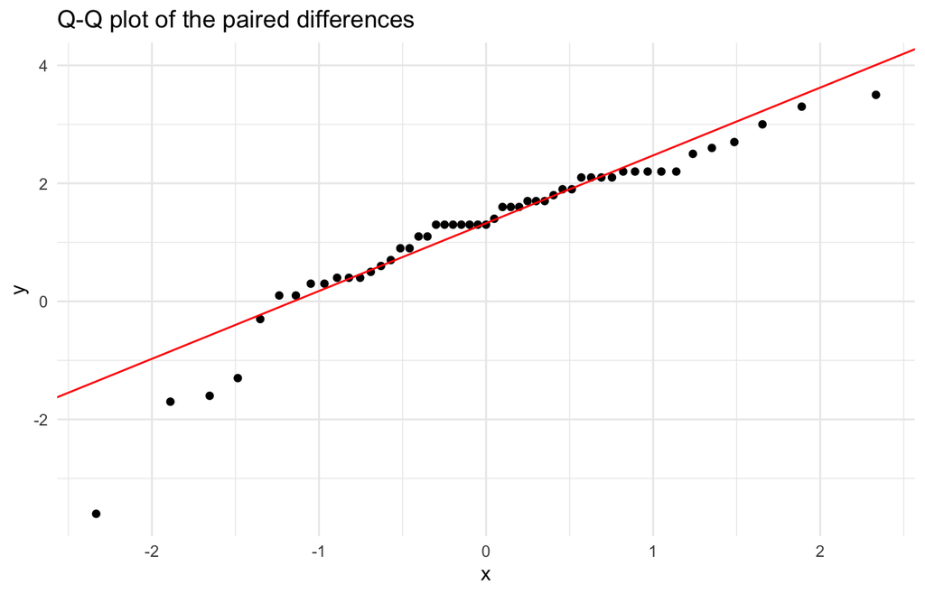

```r
ggplot(diabetes_wide, aes(sample = difference)) +
  stat_qq() +
  stat_qq_line(color = "red") +
  labs(title = "Q-Q plot of the paired differences") +
  theme_minimal()
```

```r
shapiro_diff <- shapiro.test(diabetes_wide$difference)
shapiro_diff
```

```
##
##  Shapiro-Wilk normality test
##
## data:  diabetes_wide$difference
## W = 0.90824, p-value = 0.0008018
```

The Shapiro-Wilk p-value is 0.0008, which is below 0.05, so the differences are **not** normally distributed. The histogram shows a few states on the left side where women had higher prevalence than men (the lowest was Louisiana, at -3.6 points).

Because the normality assumption is not met, I used the **Wilcoxon signed-rank test** as my main test. It is the non-parametric version of the paired t-test and does not need normal data. With 51 pairs the paired t-test is fairly robust, so I also ran it to check that both tests agree.

### Wilcoxon signed-rank test (main test)

```r
wilcox_result <- wilcox.test(diabetes_wide$Male, diabetes_wide$Female,
                             paired = TRUE)
wilcox_result
```

```
##
##  Wilcoxon signed rank test with continuity correction
##
## data:  diabetes_wide$Male and diabetes_wide$Female
## V = 1189, p-value = 8.35e-07
## alternative hypothesis: true location shift is not equal to 0
```

### Paired t-test (check)

```r
t_result <- t.test(diabetes_wide$Male, diabetes_wide$Female, paired = TRUE)
t_result
```

```
##
##  Paired t-test
##
## data:  diabetes_wide$Male and diabetes_wide$Female
## t = 6.6992, df = 50, p-value = 1.774e-08
## alternative hypothesis: true mean difference is not equal to 0
## 95 percent confidence interval:
##  0.8553189 1.5878183
## sample estimates:
## mean difference
##        1.221569
```

### Results

- Wilcoxon signed-rank test: V = 1189, p = 8.4e-07
- Paired t-test: t(50) = 6.7, p = 1.8e-08
- Median difference (male - female): 1.3 percentage points
- Mean difference: 1.22 percentage points (95% CI 0.86 to 1.59)

### Visualization supporting the test

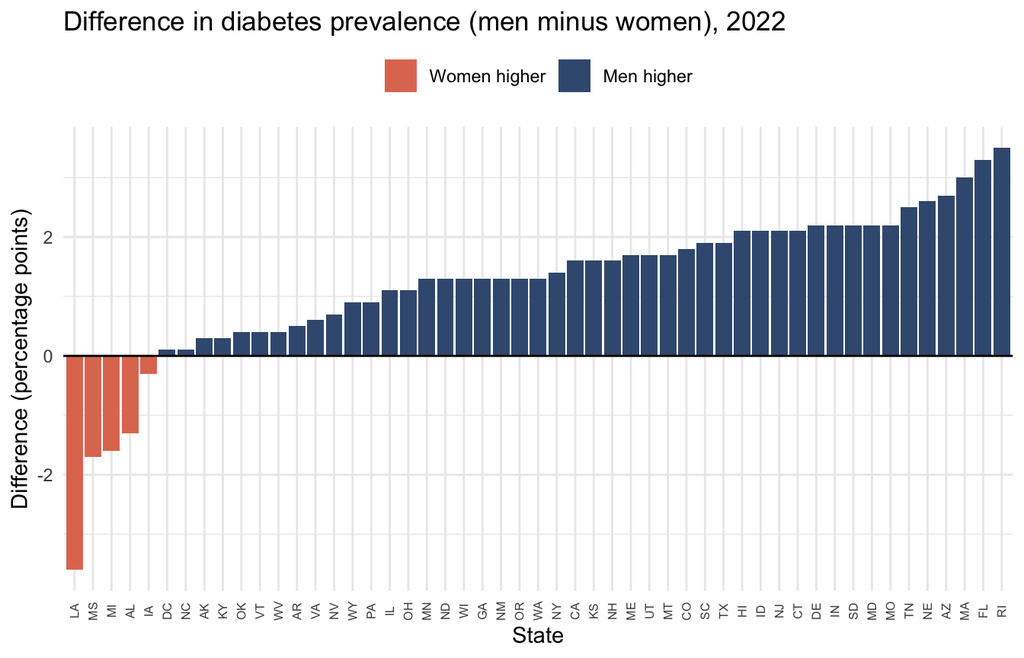

```r
ggplot(diabetes_wide, aes(x = reorder(state, difference), y = difference,
                          fill = difference > 0)) +
  geom_col() +
  geom_hline(yintercept = 0) +
  scale_fill_manual(values = c("TRUE" = "#3D5A80", "FALSE" = "#E07A5F"),
                    labels = c("TRUE" = "Men higher", "FALSE" = "Women higher"),
                    name = NULL) +
  labs(title = "Difference in diabetes prevalence (men minus women), 2022",
       x = "State", y = "Difference (percentage points)") +
  theme_minimal() +
  theme(axis.text.x = element_text(angle = 90, vjust = 0.5, size = 6),
        legend.position = "top")
```

### Interpretation

The p-value is far below 0.05, so I reject the null hypothesis. In 2022, adult men had a higher diabetes prevalence than adult women in most U.S. states, by about 1.2 percentage points on average. Both tests gave the same conclusion.

A difference of about 1 percentage point sounds small, but since the average rate for women is around 10%, men’s rate is about 12% higher in relative terms.

### Type I and Type II errors

- **Type I error:** rejecting H0 when there really is no difference. Here, that would mean concluding men have more diabetes when they actually don’t. Using α = 0.05 means that if there were truly no difference, we would still get a “significant” result about 5% of the time. Our p-value is far below 0.05, so this result is unlikely to be a false positive, but it can’t be ruled out completely.
- **Type II error:** failing to reject H0 when there really is a difference. Since we did reject H0, we can’t have made a Type II error in this analysis. It would have been more of a risk with fewer states or a smaller real difference.

## Regression: obesity and diabetes

Regression makes sense here as a follow-up question: **do states with higher adult obesity also have higher adult diabetes?** Both are age-adjusted 2022 BRFSS prevalences for the same 51 locations, so they line up one-to-one by state.

- **Outcome:** diabetes prevalence (%)
- **Predictor:** obesity prevalence (%)

Since both variables are continuous, I used simple linear regression.

```r
obesity_overall <- cdi %>%
  filter(Question == "Obesity among adults",
         DataSource == "BRFSS",
         YearStart == 2022,
         DataValueType == "Age-adjusted Prevalence",
         StratificationCategory1 == "Overall",
         !LocationAbbr %in% c("US", "GU", "PR", "VI")) %>%
  select(state = LocationAbbr, obesity = DataValue)

state_data <- diabetes_overall %>%
  select(state, LocationDesc, diabetes = prevalence) %>%
  inner_join(obesity_overall, by = "state")

nrow(state_data)
```

```
## [1] 51
```

```r
summary(state_data$obesity)
```

```
##    Min. 1st Qu.  Median    Mean 3rd Qu.    Max.
##   25.00   31.35   33.90   34.06   37.60   41.50
```

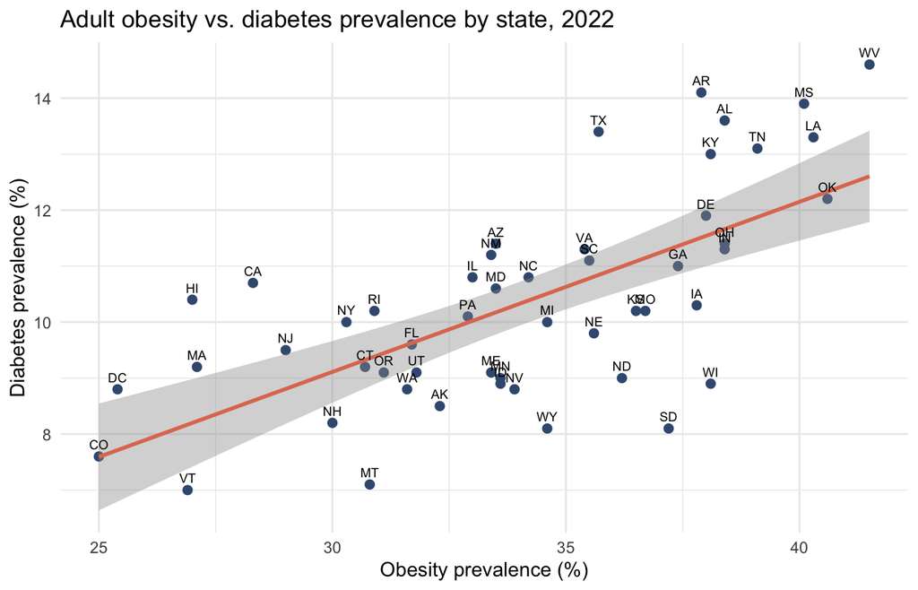

```r
ggplot(state_data, aes(x = obesity, y = diabetes)) +
  geom_point(color = "#3D5A80", size = 2) +
  geom_smooth(method = "lm", color = "#E07A5F") +
  geom_text(aes(label = state), size = 2.5, vjust = -0.8) +
  labs(title = "Adult obesity vs. diabetes prevalence by state, 2022",
       x = "Obesity prevalence (%)", y = "Diabetes prevalence (%)") +
  theme_minimal()
```

```r
model <- lm(diabetes ~ obesity, data = state_data)
summary(model)
```

```
##
## Call:
## lm(formula = diabetes ~ obesity, data = state_data)
##
## Residuals:
##     Min      1Q  Median      3Q     Max
## -3.1970 -0.9782 -0.0268  1.0135  2.5904
##
## Coefficients:
##              Estimate Std. Error t value Pr(>|t|)
## (Intercept) 0.0005025  1.6404686   0.000        1
## obesity     0.3036698  0.0478269   6.349 6.76e-08 ***
## ---
## Signif. codes:  0 '***' 0.001 '**' 0.01 '*' 0.05 '.' 0.1 ' ' 1
##
## Residual standard error: 1.387 on 49 degrees of freedom
## Multiple R-squared:  0.4514, Adjusted R-squared:  0.4402
## F-statistic: 40.31 on 1 and 49 DF,  p-value: 6.757e-08
```

### Checking model assumptions

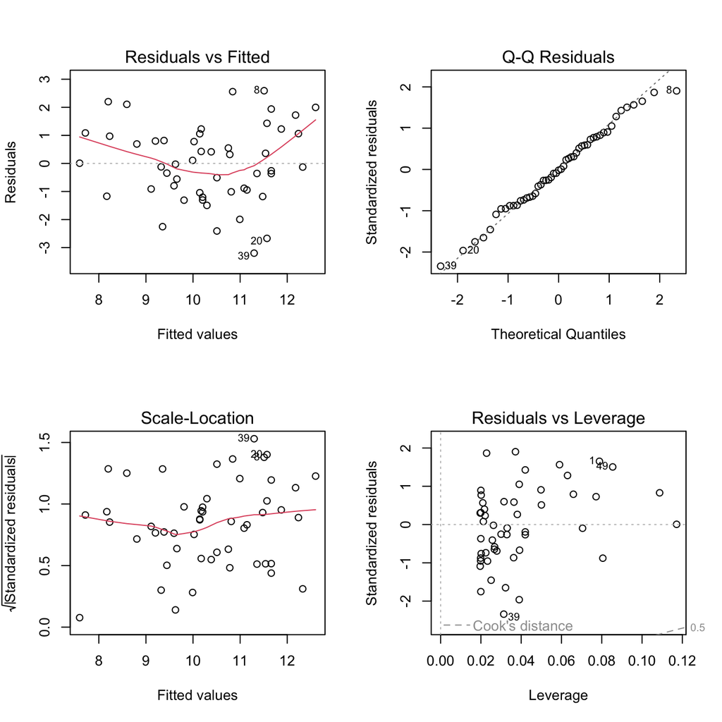

```r
par(mfrow = c(2, 2))
plot(model)
```

```r
par(mfrow = c(1, 1))

shapiro_resid <- shapiro.test(resid(model))
shapiro_resid
```

```
##
##  Shapiro-Wilk normality test
##
## data:  resid(model)
## W = 0.98637, p-value = 0.8203
```

- **Linearity:** the scatterplot looks roughly linear. The red line in Residuals vs Fitted bends up a little at both ends, mostly because a few states (like Arkansas, Texas, Hawaii, and California) sit above the line. It’s a mild pattern, so a straight line is still a reasonable fit.
- **Normal residuals:** the Q-Q plot follows the line, and the Shapiro-Wilk test on the residuals is not significant (p = 0.82).
- **Equal variance:** the Scale-Location plot shows a fairly even spread across fitted values.
- **Influential points:** no point stands out past Cook’s distance lines in the Residuals vs Leverage plot.
- **Independence:** each state is one observation. Neighboring states can be similar, which is a limitation.

### Interpreting the model

- **Slope:** for every 1 percentage point increase in a state’s obesity prevalence, diabetes prevalence was about 0.3 points higher (p = 6.8e-08). So a state with 10 points more obesity would be expected to have about 3 points more diabetes.
- **Intercept:** 0. This would be the predicted diabetes rate at 0% obesity, which is far outside the data, so it doesn’t have a real-world meaning here.
- **Model fit:** R² = 0.45, so obesity explains about 45% of the state-to-state variation in diabetes.

This is a state-level association, not a cause-and-effect result, and it doesn’t tell us about individual people (this is called the ecological fallacy). Other factors like income, age, race/ethnicity, and access to healthcare likely explain the rest of the variation.

## Conclusions

- In 2022, men had higher age-adjusted diabetes prevalence than women in 46 of the 51 locations (50 states + DC), with an average gap of about 1.2 percentage points. This difference was statistically significant (Wilcoxon signed-rank p = 8.4e-07).
- States with higher adult obesity had higher adult diabetes. Obesity explained about 45% of the differences between states.

## Limitations

- BRFSS is a phone survey and diabetes is **self-reported**, so people with undiagnosed diabetes are missed.
- The values are **state estimates**, not individual data. Each estimate has its own margin of error (the confidence limit columns), which these tests don’t account for.
- The data don’t separate type 1 and type 2 diabetes.
- The data are from one year (2022) and only for sex, so this can’t show trends over time or explain *why* men have higher rates.